# BLS Wichita Software Developer Salaries

```r
source(paste0(getwd(), '/analysis.r'))
```

- How many developers are in Wichita?

| Location | TotalEmployment | Per1000Jobs |
| --- | --- | --- |
| Des Moines-West Des Moines, IA | 5090 | 14.02400 |
| Kansas City, MO-KS | 15150 | 14.35500 |
| National | 1617400 | 11.34625 |
| Oklahoma City, OK | 5450 | 9.02500 |
| Omaha-Council Bluffs, NE-IA | 7200 | 14.80400 |
| Tulsa, OK | 2400 | 5.59600 |
| Wichita, KS | 1600 | 5.37100 |

where “developer” is defined as one of the following:

```r
occupations
```

```
[1] "Web Developers"                        "Software Developers, Applications"
[3] "Software Developers, Systems Software" "Computer Programmers"
```

- What % of Wichita’s labor market is the dev community? % of employment:

```r
valueToPctStr(pull(location_data %>% filter(Location == 'Wichita, KS'), TotalEmployment) / wichita$TotalEmployment)
```

```
[1] "0.5%"
```

% of total salary dollars:

```r
valueToPctStr(pull(location_data %>% filter(Location == 'Wichita, KS'), TotalSalary) / wichita$TotalSalary)
```

```
[1] "1.0%"
```

- Does Wichita have a dev shortage?

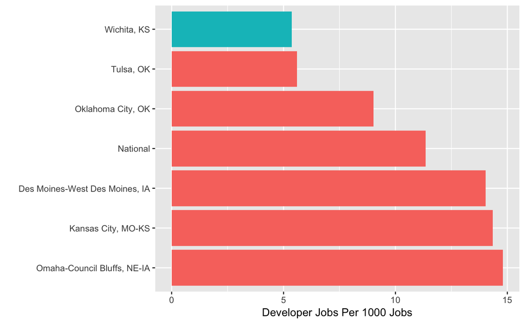

```r
plot_per1000ByLocation
```

- If so, how much $ would it be worth to Wichita to remedy this?
- How do the salary ranges compare to the salary survey?

There is no perfect way to compare the ranges, despite having percentile information from BLS, because we can’t aggregate them into our overall developer category. We could compare by role – web developer, for example – but that increases the estimation error and probably creates more problems than it solves.

For a simple comparison, the mean salary from the salary surveys were $68,640 and $77,380 for 2017 and 2018, respectively, compared to a mean salary from the BLS data of:

```r
mean_salary <- location_data %>% filter(Location == wichita_area_name) %>% pull(MeanSalary)
mean_salary
```

```
[1] 81572.94
```

This represents a difference of

```r
valueToPctStr(mean_salary / 68640 - 1)
```

```
[1] "18.8%"
```

and

```r
valueToPctStr(mean_salary / 77380 - 1)
```

```
[1] "5.4%"
```

relative to the 2017 and 2018 survey figures, respectively.

- How does the average Wichita dev salary compare to regional peers, RPP adjusted?

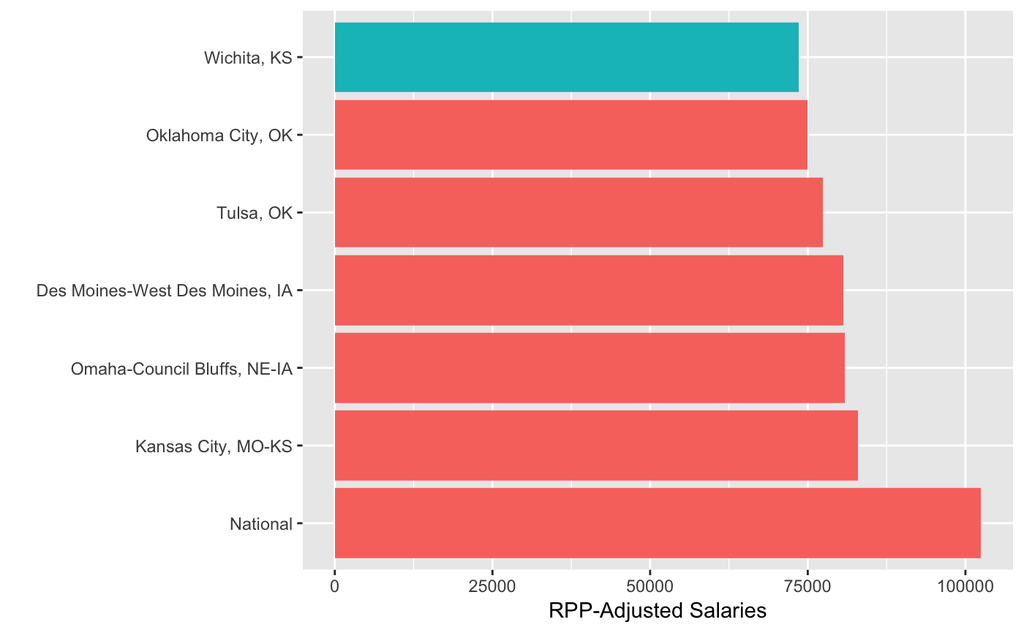

```r
plot_rppAdjustedSalaryByLocation
```

Note the RPP values are from 2016 while the salary values are from 2017. Since we are comparing on an MSA relative basis, this difference is negligible.

- How does the average Wichita dev salary compare to tech hubs, RPP adjusted?
- Ideally, nationally, but be careful with applying person-weighted RPPs to developer-weighted average income figures. Ie, if devs tend to live in high RPP areas, using the national RPP doesn’t make sense.